# Dimensionality reduction techniques

# 5. Dimensionality reduction techniques

This week’s tasks present dimensionality reduction techniques. Principal Component Analysis (PCA) will be applied.

The R script file that created the data file can be viewed [here](https://github.com/MikkoPatronen/IODS-project/blob/master/data/create_human.R). Let us view information about the data:

## 5.1 Summary of the variables in the data:

```r
rm(list=ls())
library(dplyr)
```

```r
library(ggplot2)
library(GGally)
library(tidyr)
library(MASS)
library(corrplot)
human <- read.table("human.txt")
str(human)
```

```
## 'data.frame':    155 obs. of  8 variables:
##  $ Edu2.FM  : num  0.198 0.931 0.861 0.977 0.989 ...
##  $ Labo.FM  : num  0.199 0.685 0.211 0.633 0.747 ...
##  $ Edu.Exp  : num  9.3 11.8 14 17.9 12.3 20.2 15.7 11.9 12.6 14.4 ...
##  $ Life.Exp : num  60.4 77.8 74.8 76.3 74.7 82.4 81.4 70.8 75.4 76.6 ...
##  $ GNI      : int  1885 9943 13054 22050 8124 42261 43869 16428 21336 38599 ...
##  $ Mat.Mor  : int  400 21 89 69 29 6 4 26 37 22 ...
##  $ Ado.Birth: num  86.8 15.3 10 54.4 27.1 12.1 4.1 40 28.5 13.8 ...
##  $ Parli.F  : num  27.6 20.7 25.7 36.8 10.7 30.5 30.3 15.6 16.7 15 ...
```

The data includes 155 observations of 8 variables. They are:

- **Edu2.FM** - the ratio of female and male populations with secondary education in each country
- **Labo.FM** - the ratio of labour force participation of females and males in each country
- **Life.Exp** - life expectancy at birth
- **Edu.Exp** - Expected years of schooling (years)
- **GNI** - The gross national income
- **Mat.Mor** - The maternal mortality ratio
- **Ado.Birth** - the adolescent birth rate
- **Parli.F** - the share of parliamentary seats held by women

## Graphical overview of the data

```r
summary(human)
```

```
##     Edu2.FM          Labo.FM          Edu.Exp         Life.Exp
##  Min.   :0.1717   Min.   :0.1857   Min.   : 5.40   Min.   :49.00
##  1st Qu.:0.7264   1st Qu.:0.5984   1st Qu.:11.25   1st Qu.:66.30
##  Median :0.9375   Median :0.7535   Median :13.50   Median :74.20
##  Mean   :0.8529   Mean   :0.7074   Mean   :13.18   Mean   :71.65
##  3rd Qu.:0.9968   3rd Qu.:0.8535   3rd Qu.:15.20   3rd Qu.:77.25
##  Max.   :1.4967   Max.   :1.0380   Max.   :20.20   Max.   :83.50
##       GNI            Mat.Mor         Ado.Birth         Parli.F
##  Min.   :   581   Min.   :   1.0   Min.   :  0.60   Min.   : 0.00
##  1st Qu.:  4198   1st Qu.:  11.5   1st Qu.: 12.65   1st Qu.:12.40
##  Median : 12040   Median :  49.0   Median : 33.60   Median :19.30
##  Mean   : 17628   Mean   : 149.1   Mean   : 47.16   Mean   :20.91
##  3rd Qu.: 24512   3rd Qu.: 190.0   3rd Qu.: 71.95   3rd Qu.:27.95
##  Max.   :123124   Max.   :1100.0   Max.   :204.80   Max.   :57.50
```

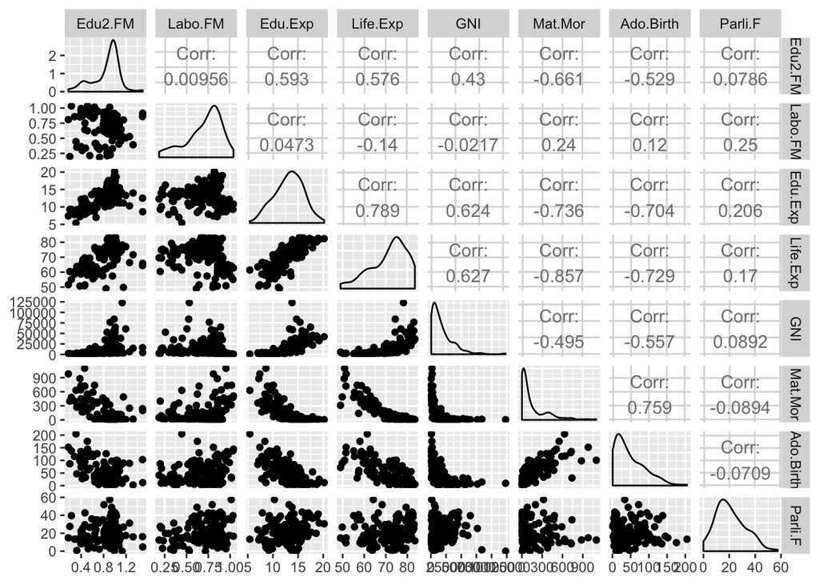

```r
ggpairs(human)
```

Since the variables are not scaled, the means are quite different across variables.

The ggpairs()-plot shows distributions of the variables and shows the correlations between the variables. The first four of the variables (Edu2.FM, Labo.FM, Edu.Exp and Life.Exp) have negative skewness and the remaining four variables are positively skewed.

The corrplot() visualizes correlations between variables:

```r
cor(human)
```

```
##                Edu2.FM      Labo.FM     Edu.Exp   Life.Exp         GNI
## Edu2.FM    1.000000000  0.009564039  0.59325156  0.5760299  0.43030485
## Labo.FM    0.009564039  1.000000000  0.04732183 -0.1400125 -0.02173971
## Edu.Exp    0.593251562  0.047321827  1.00000000  0.7894392  0.62433940
## Life.Exp   0.576029853 -0.140012504  0.78943917  1.0000000  0.62666411
## GNI        0.430304846 -0.021739705  0.62433940  0.6266641  1.00000000
## Mat.Mor   -0.660931770  0.240461075 -0.73570257 -0.8571684 -0.49516234
## Ado.Birth -0.529418415  0.120158862 -0.70356489 -0.7291774 -0.55656208
## Parli.F    0.078635285  0.250232608  0.20608156  0.1700863  0.08920818
##              Mat.Mor  Ado.Birth     Parli.F
## Edu2.FM   -0.6609318 -0.5294184  0.07863528
## Labo.FM    0.2404611  0.1201589  0.25023261
## Edu.Exp   -0.7357026 -0.7035649  0.20608156
## Life.Exp  -0.8571684 -0.7291774  0.17008631
## GNI       -0.4951623 -0.5565621  0.08920818
## Mat.Mor    1.0000000  0.7586615 -0.08944000
## Ado.Birth  0.7586615  1.0000000 -0.07087810
## Parli.F   -0.0894400 -0.0708781  1.00000000
```

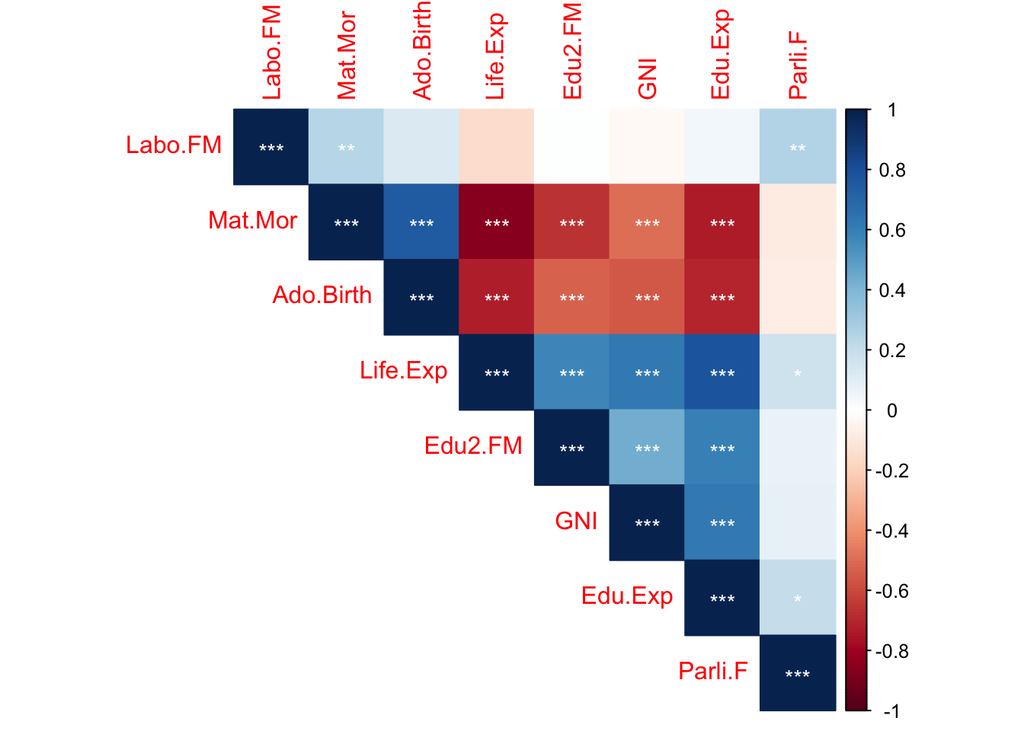

```r
res1 <- cor.mtest(human, conf.level = .95)

cor(human) %>% corrplot(p.mat = res1$p, method = "color", type = "upper",
sig.level = c(.001, .01, .05), pch.cex = .9,
insig = "label_sig", pch.col = "white", order = "AOE")
```

Blue color means positive correlation and red negative correlation. Lighter colors mean weaker association and darker colors stronger.

## 5.2. Principal Component Analysis (PCA) on the non-standardized dataset

Next we will conduct a principal component analysis (PCA) on the not standardized human data and show the variability captured by the principal components. A biplot will be drawn to display the observations by the first two principal components.

```r
# create and print out a summary of pca_human
pca_human <- prcomp(human)
s <- summary(pca_human)
s
```

```
## Importance of components:
##                              PC1      PC2   PC3   PC4   PC5   PC6    PC7
## Standard deviation     1.854e+04 185.5219 25.19 11.45 3.766 1.566 0.1912
## Proportion of Variance 9.999e-01   0.0001  0.00  0.00 0.000 0.000 0.0000
## Cumulative Proportion  9.999e-01   1.0000  1.00  1.00 1.000 1.000 1.0000
##                           PC8
## Standard deviation     0.1591
## Proportion of Variance 0.0000
## Cumulative Proportion  1.0000
```

```r
# rounded percetanges of variance captured by each PC
pca_pr <- 100*round(1*s$importance[2, ], digits = 3)

# print out the percentages of variance
pca_pr
```

```
## PC1 PC2 PC3 PC4 PC5 PC6 PC7 PC8
## 100   0   0   0   0   0   0   0
```

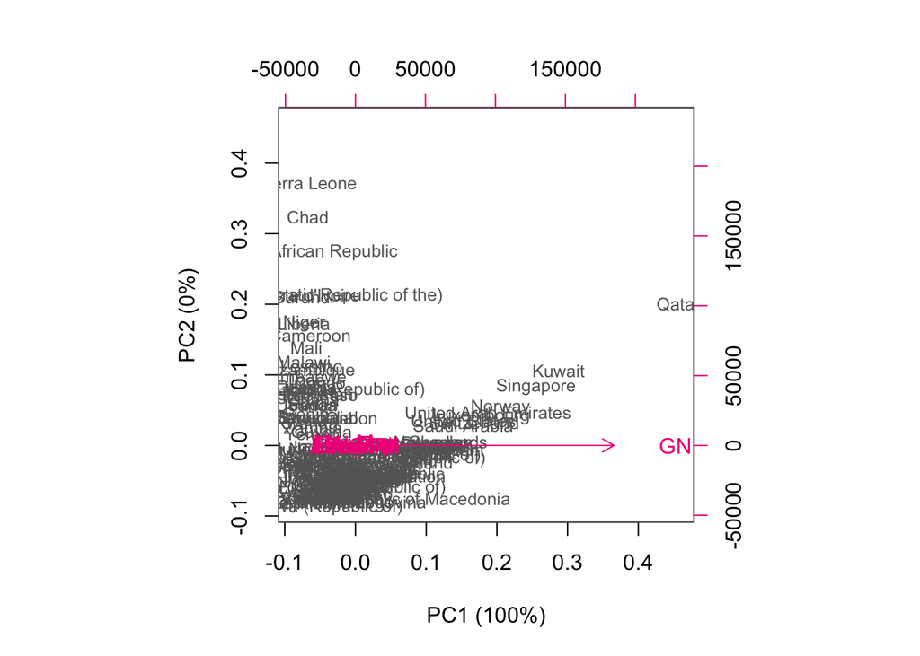

```r
# create object pc_lab to be used as axis labels
pc_lab<-paste0(names(pca_pr), " (", pca_pr, "%)")

# draw a biplot
biplot(pca_human, cex = c(0.8, 1), col = c("grey40", "deeppink2"), xlab = pc_lab[1], ylab = pc_lab[2])
```

## 5.3. Same with standardized data

Let us standardize the data and then perform the PCA again:

```r
# standardize the variables
human_std <- scale(human)

# print out summaries of the standardized variables
summary(human_std)
```

```
##     Edu2.FM           Labo.FM           Edu.Exp           Life.Exp
##  Min.   :-2.8189   Min.   :-2.6247   Min.   :-2.7378   Min.   :-2.7188
##  1st Qu.:-0.5233   1st Qu.:-0.5484   1st Qu.:-0.6782   1st Qu.:-0.6425
##  Median : 0.3503   Median : 0.2316   Median : 0.1140   Median : 0.3056
##  Mean   : 0.0000   Mean   : 0.0000   Mean   : 0.0000   Mean   : 0.0000
##  3rd Qu.: 0.5958   3rd Qu.: 0.7350   3rd Qu.: 0.7126   3rd Qu.: 0.6717
##  Max.   : 2.6646   Max.   : 1.6632   Max.   : 2.4730   Max.   : 1.4218
##       GNI             Mat.Mor          Ado.Birth          Parli.F
##  Min.   :-0.9193   Min.   :-0.6992   Min.   :-1.1325   Min.   :-1.8203
##  1st Qu.:-0.7243   1st Qu.:-0.6496   1st Qu.:-0.8394   1st Qu.:-0.7409
##  Median :-0.3013   Median :-0.4726   Median :-0.3298   Median :-0.1403
##  Mean   : 0.0000   Mean   : 0.0000   Mean   : 0.0000   Mean   : 0.0000
##  3rd Qu.: 0.3712   3rd Qu.: 0.1932   3rd Qu.: 0.6030   3rd Qu.: 0.6127
##  Max.   : 5.6890   Max.   : 4.4899   Max.   : 3.8344   Max.   : 3.1850
```

```r
# create and print out a summary of pca_human
pca_human <- prcomp(human_std)

s <- summary(pca_human)
s
```

```
## Importance of components:
##                           PC1    PC2     PC3     PC4     PC5     PC6
## Standard deviation     2.0708 1.1397 0.87505 0.77886 0.66196 0.53631
## Proportion of Variance 0.5361 0.1624 0.09571 0.07583 0.05477 0.03595
## Cumulative Proportion  0.5361 0.6984 0.79413 0.86996 0.92473 0.96069
##                            PC7     PC8
## Standard deviation     0.45900 0.32224
## Proportion of Variance 0.02634 0.01298
## Cumulative Proportion  0.98702 1.00000
```

```r
# rounded percetanges of variance captured by each PC
pca_pr <- 100*round(1*s$importance[2, ], digits = 3)

# print out the percentages of variance
pca_pr
```

```
##  PC1  PC2  PC3  PC4  PC5  PC6  PC7  PC8
## 53.6 16.2  9.6  7.6  5.5  3.6  2.6  1.3
```

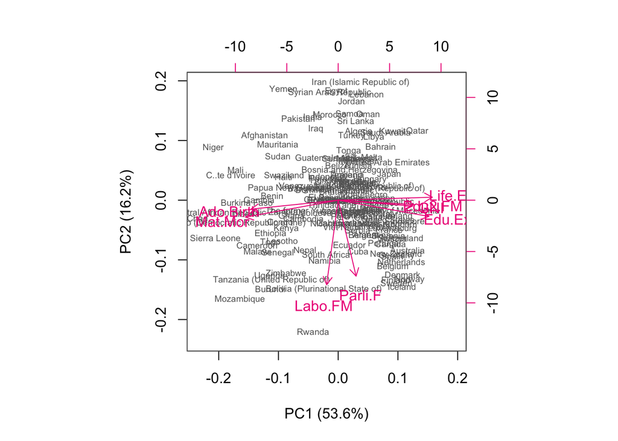

```r
# create object pc_lab to be used as axis labels
pc_lab<-paste0(names(pca_pr), " (", pca_pr, "%)")

# draw a biplot
biplot(pca_human, cex = c(0.6, 1), col = c("grey40", "deeppink2"), xlab = pc_lab[1], ylab = pc_lab[2])
```

Standardizing the data makes a big difference. The results from un-standardized and standardized datas are very different: the results from un-standardized variables showed that PC1 captures all the variation, but with standardized variables PC1 now captures 53,6% (PC2 captures 16,2% and PC3 9,6%).

## 5.4 Personal interpretations

PCA reduces dimensions of a dataset into components that explain the variance in the data. The arrows of the variables can be interpreted so that the PC1 consists of Mat.Mor, Ado.Birth, Edu.Exp, Edu2.FM, Life.Exp and GNI. PC2 consists of Parli.F and Labo.FM. PC1 explains 53,6% of the variance in the data. PC2 explains 16,2% of the variance.

## 5.5 Multiple Correspondence Analysis

The structure and the dimensions of the data:

I picked the variables “breakfast”, “evening”, “sex”, “sugar”, “where”, “lunch” to form my subdata. Here is some information about the structure of the data and some visualizations:

```r
library(FactoMineR)
library(tidyr)
library(dplyr)

data("tea")

tea_mca = tea[, c("breakfast", "evening", "sex", "sugar", "where", "lunch")]

summary(tea_mca)
```

```
##          breakfast          evening    sex          sugar
##  breakfast    :144   evening    :103   F:178   No.sugar:155
##  Not.breakfast:156   Not.evening:197   M:122   sugar   :145
##
##                   where           lunch
##  chain store         :192   lunch    : 44
##  chain store+tea shop: 78   Not.lunch:256
##  tea shop            : 30
```

```r
str(tea_mca)
```

```
## 'data.frame':    300 obs. of  6 variables:
##  $ breakfast: Factor w/ 2 levels "breakfast","Not.breakfast": 1 1 2 2 1 2 1 2 1 1 ...
##  $ evening  : Factor w/ 2 levels "evening","Not.evening": 2 2 1 2 1 2 2 1 2 1 ...
##  $ sex      : Factor w/ 2 levels "F","M": 2 1 1 2 2 2 2 1 2 2 ...
##  $ sugar    : Factor w/ 2 levels "No.sugar","sugar": 2 1 1 2 1 1 1 1 1 1 ...
##  $ where    : Factor w/ 3 levels "chain store",..: 1 1 1 1 1 1 1 1 2 2 ...
##  $ lunch    : Factor w/ 2 levels "lunch","Not.lunch": 2 2 2 2 2 2 2 2 2 2 ...
```

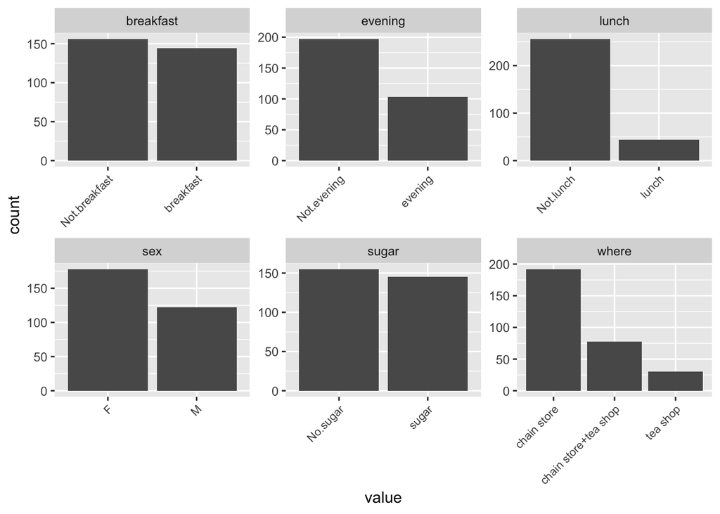

```r
gather(tea_mca) %>% ggplot(aes(value)) + facet_wrap("key", scales = "free") +geom_bar()+theme(axis.text.x = element_text(angle = 45, hjust = 1, size = 8))
```

The dataset tea_mca consists of 300 observations of 6 variables.

## MCA:

```r
mca <- MCA(tea_mca, graph = FALSE)

summary(mca)
```

```
##
## Call:
## MCA(X = tea_mca, graph = FALSE)
##
##
## Eigenvalues
##                        Dim.1   Dim.2   Dim.3   Dim.4   Dim.5   Dim.6
## Variance               0.216   0.198   0.178   0.171   0.154   0.132
## % of var.             18.552  16.987  15.288  14.679  13.222  11.317
## Cumulative % of var.  18.552  35.538  50.827  65.506  78.727  90.045
##                        Dim.7
## Variance               0.116
## % of var.              9.955
## Cumulative % of var. 100.000
##
## Individuals (the 10 first)
##                         Dim.1    ctr   cos2    Dim.2    ctr   cos2
## 1                    |  0.408  0.257  0.206 | -0.315  0.167  0.122 |
## 2                    | -0.567  0.495  0.487 | -0.272  0.124  0.112 |
## 3                    | -0.095  0.014  0.010 |  0.194  0.063  0.043 |
## 4                    |  0.601  0.556  0.460 | -0.364  0.223  0.169 |
## 5                    |  0.203  0.063  0.040 |  0.089  0.013  0.008 |
## 6                    |  0.116  0.021  0.018 | -0.475  0.379  0.296 |
## 7                    | -0.077  0.009  0.007 | -0.426  0.305  0.230 |
## 8                    | -0.095  0.014  0.010 |  0.194  0.063  0.043 |
## 9                    | -0.371  0.212  0.117 | -0.221  0.082  0.042 |
## 10                   | -0.091  0.013  0.006 |  0.294  0.145  0.062 |
##                       Dim.3    ctr   cos2
## 1                     0.447  0.373  0.246 |
## 2                     0.028  0.001  0.001 |
## 3                    -0.740  1.022  0.632 |
## 4                    -0.153  0.044  0.030 |
## 5                     0.218  0.089  0.046 |
## 6                    -0.214  0.086  0.060 |
## 7                     0.386  0.278  0.188 |
## 8                    -0.740  1.022  0.632 |
## 9                     0.712  0.948  0.434 |
## 10                    0.544  0.554  0.211 |
##
## Categories (the 10 first)
```

[output cut: 16 more lines]

```
## F                      0.041   3.493 |  -0.368   7.526   0.198  -7.695 |
## M                      0.041  -3.493 |   0.538  10.981   0.198   7.695 |
## No.sugar               0.022  -2.561 |  -0.075   0.270   0.006  -1.338 |
## sugar                  0.022   2.561 |   0.080   0.289   0.006   1.338 |
## chain store            0.004  -1.050 |  -0.327   6.398   0.190  -7.541 |
## chain store+tea shop   0.089   5.147 |   0.500   6.081   0.088   5.128 |
##
## Categorical variables (eta2)
##                        Dim.1 Dim.2 Dim.3
## breakfast            | 0.072 0.004 0.577 |
## evening              | 0.137 0.426 0.041 |
## sex                  | 0.452 0.041 0.198 |
## sugar                | 0.458 0.022 0.006 |
## where                | 0.178 0.170 0.196 |
## lunch                | 0.001 0.526 0.052 |
```

The summary of the MCA lists the explained variances. The first dimension explains 18,55% of the variance the second dimension explains 16,99%, the third 15,29%.

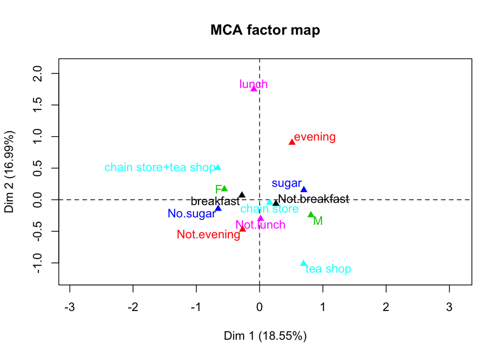

```r
plot(mca, invisible=c("ind"), habillage="quali")
```